# NBA Data Exploration and Predictive Modeling

Now let us examine turnovers and offensive rebounds.

```
Bootstrap Model
Overall, the model correctly predicts: 66.48% of game outcomes
Overall, the model correctly predicts: 58.42% of close outcomes
Overall, the model correctly predicts: 69.81% of blowout outcomes
```

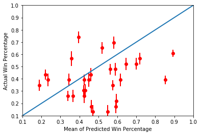

```
Bootstrap Model
Overall, the model correctly predicts: 66.72% of game outcomes
Overall, the model correctly predicts: 57.37% of close outcomes
Overall, the model correctly predicts: 70.66% of blowout outcomes
```

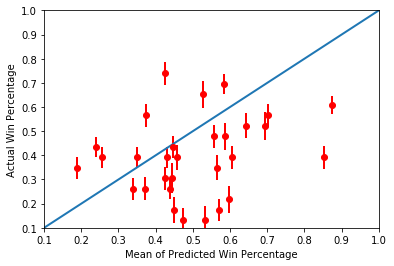

```
Bootstrap Model
Overall, the model correctly predicts: 66.64% of game outcomes
Overall, the model correctly predicts: 57.37% of close outcomes
Overall, the model correctly predicts: 70.99% of blowout outcomes
```

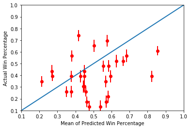

```
Bootstrap Model
Overall, the model correctly predicts: 66.31% of game outcomes
Overall, the model correctly predicts: 61.05% of close outcomes
Overall, the model correctly predicts: 70.83% of blowout outcomes
```

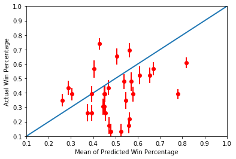

```
Bootstrap Model
Overall, the model correctly predicts: 65.42% of game outcomes
Overall, the model correctly predicts: 56.32% of close outcomes
Overall, the model correctly predicts: 68.97% of blowout outcomes
```

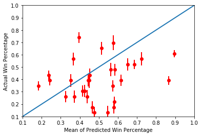

```
Bootstrap Model
Overall, the model correctly predicts: 66.88% of game outcomes
Overall, the model correctly predicts: 59.47% of close outcomes
Overall, the model correctly predicts: 70.83% of blowout outcomes
```

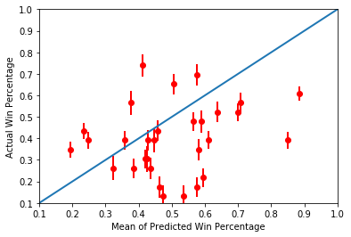

```
Bootstrap Model
Overall, the model correctly predicts: 65.58% of game outcomes
Overall, the model correctly predicts: 60.00% of close outcomes
Overall, the model correctly predicts: 69.14% of blowout outcomes
```

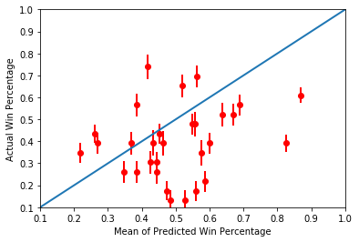

```
Bootstrap Model
Overall, the model correctly predicts: 65.17% of game outcomes
Overall, the model correctly predicts: 58.95% of close outcomes
Overall, the model correctly predicts: 69.48% of blowout outcomes
```

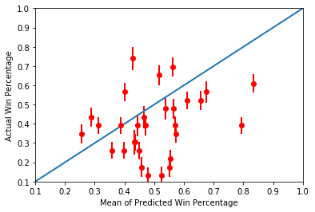

```
(0.39182844377330173, 0.0)
(0.39405786398036008, 0.0)
(0.23724094217446742, 0.0)
```

Giving the lack of significant positive improvement in accuracy, the risk of overfitting, and runtime, we will not utilize any additional adjustments to the baseline model besides adjusting for historical margins. Using this historical margins adjusted model, let us now predict the results for the 2014 season for both the fitted chi model and the bootstrap model.

```
                      Date  margins
matches
CLE,WAS  Tue, Oct 30, 2012     10.0
LAL,DAL  Tue, Oct 30, 2012     -8.0
MIA,BOS  Tue, Oct 30, 2012     13.0
CHI,SAC  Wed, Oct 31, 2012      6.0
DET,HOU  Wed, Oct 31, 2012     -9.0
```

```
Bootstrap Model
Overall, the model correctly predicts: 53.82% of game outcomes
Overall, the model correctly predicts: 55.56% of close outcomes
Overall, the model correctly predicts: 58.87% of blowout outcomes
```

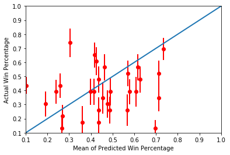

```
fatiguelife Model
Overall, the model correctly predicts: 56.00% of game outcomes
Overall, the model correctly predicts: 64.44% of close outcomes
Overall, the model correctly predicts: 58.06% of blowout outcomes
```

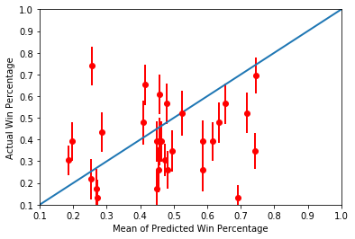

Above, for both the fitted model and the bootstrap model, the overall accuracy was around 55%, slightly higher than 50% chance. Interestingly, both accuracy for close games and blowouts were above chance at 55% and 60% respectively.

Looking at the graphs, we can see that both models have high errors, most likely due to the low number of games played so far in 2014. It also appears that, for most team, both models are overpredicting their win percentages. Again, this may be due to the low number of games; perhaps some of the better teams are just having a rough start to the season. The calibration of the model is significantly lower than for 2013, with many points failing to emcompass the blue line.

# Bayesian Analysis:

## Building on the Points-only Model: Using ABPRmetrics to account for Possessions

#### APBRmetrics

The Association for Professional Basketball Research Metrics refers to the analysis of basketball using statistics, much akin to sabermetrics for baseball. A key idea to APBRmetrics is that a team's performance should be evaluated based on their number of possessions. In other words, only the ratio: total points/total possessions is useful i.e. a team that score 100 points in 50 possessions is much better than a team that scores 100 points in 75 possessions.

To account for this, we will use the APBR metric Offensive Rating. Mathematically, $Offensive Rating=\frac{Points\cdot{100}}{Possessions}$ representing Total Points Scored per 100 Possessions. The formula for Possessions is given by Kubatko et. al's "A Starting Point for Analyzing Basketball Statistics," which appears as follows:

$Possessions=0.96(Field Goal Attempts - Offensive Rebounds+Turnovers+0.44\cdot{Free Throw Attempts})$

For every player and for every basketball game, we will calculate an Offensive Rating for that player for that game. Because APBRmetrics typically apples to a team on a per game basis rather than players, we will weight each player's offensive rating by the percentage of the game they actually played. We do this because if a player who plays for 30 seconds in a game shoots a 3-point shot in only 1 possession, he would get an Offensive rating of $OffRating=\frac{3\cdot{100}}{1}$ which would be extremely inaccurate compared to a player who plays 40 minutes in a game, scores 30 points, but in 20 possessions. The latter has a much more influential impact to the team than the former. By weighing Offensive Rating by % game played, players who have less game time will have lower adjusted ratings, which should be the case.

#### Frequentist Setting:

We will attempt to model each player's Offensive Rating during the NBA season ending in 2013. By looking at the distribution of players' offensive rating, we notice they are bell-shaped and many appear approximately normal. Thus, we will make a reasonable assumption that a player's 2013 Offensive Rating is distributed $OffRating\sim{N(\mu,\sigma^2)}$ where $\mu$ and $\sigma$ will be approximated by the fitted normal.

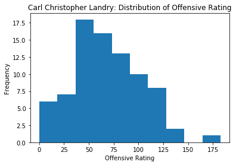

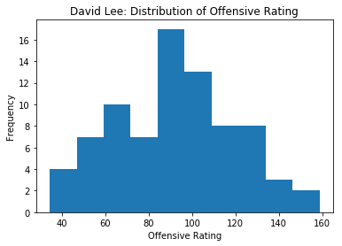

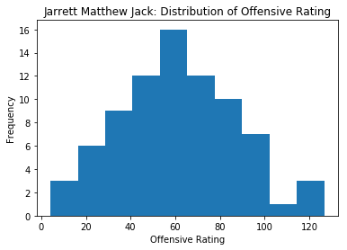

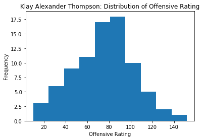

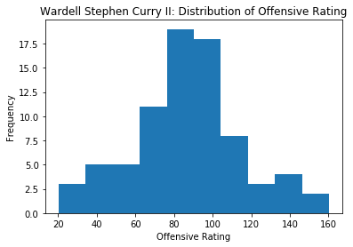

Again, by looking at the distribution of players' offensive rating, we make the assumption that a player's 2013 Offensive Rating is normally distributed. Thus, we must approximate each player's parameters of their normal offensive rating distribution, $\mu$ and $\sigma$. We do so using the module scipy.

#### Bayesian Setting:

We assume that the standard deviation $\sigma$ for a player's Offensive Rating distribution is $known$, and the mean $\mu$ is an unknown parameter with its own distribution. We make this assumption because it makes logical sense that an NBA player's volatility in his Offensive Rating for the 2014 season, is represented by the volatility he experienced during the most recently completed season, 2013. However, his true Mean Offensive Rating $\mu$, may fluctuate throughout his career due to difficult-to-model factors such as momentum, confidence, experience, etc. It may be that 2013 was just a great year for him, but typically his confidence and momentum fluctuates each season, affecting his Mean Offensive Rating $\mu$.

#### Finding a Prior:

We will find a prior distribution for each player's Mean Offensive rating $\mu$. To do so, we will look at historical player data over the past 5 years (5 completed seasons). For each player, we calculate his mean offensive rating for every month played over the past 5 seasons. We will then look at the distribution of mean offensive ratings and determine a reasonable prior.

We are modeling mean offensive rating by month because ultimately we want to predict NBA game outcomes for the month of *December 2013* in the current 2013-2014 NBA season. We will soon use the month of *November 2013* from the current NBA season to update the prior to get the posterior. We will then use this posterior to predict December game outcomes (which are happening as we speak)!

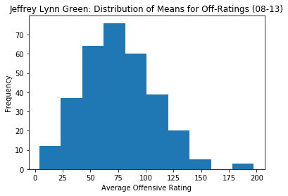

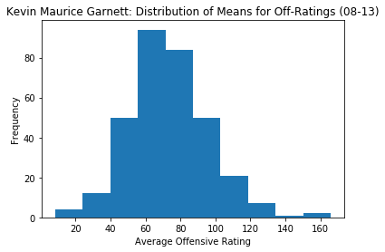

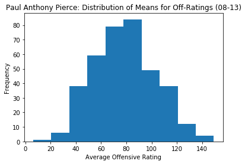

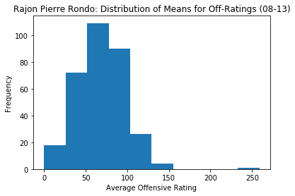

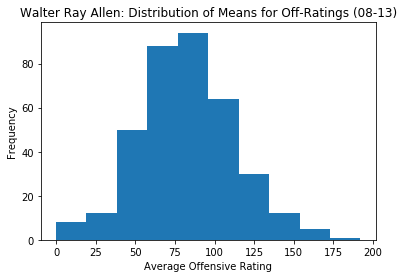

#### Assuming a Normal for the Prior Distribution:

Looking at the histograms for players' historical mean offensive ratings, we notice they are bell-shaped and appear roughly normal. Thus, we will make a reasonable assumption that mean offensive rating is normally distributed. Therefore, the prior distribution for mean offensive rating $\mu$ is as follows: $\mu\sim{N(\alpha,\beta^2)}$ where the parameters $\alpha$ and $\beta$ are constants. We will model these parameters by using, again, the scipy.stats module.

### Bayesian Model: Using Likelihood to update the Prior and calculate a Posterior

We model Offensive Rating as $Offensive Rating\sim{N(\mu,\sigma^2)}$ where st deviation $\sigma$ is $known$, and $\mu\sim{N(\alpha,\beta^2)}$. Therefore, we have a Normal-Normal conjugate-prior where we can expect the posterior distribution for $\mu$ to also be normally distributed.

The posterior distribution of $\mu$ is modeled as $f(\mu|x_i)\propto{f(x_i |\mu,\sigma)\cdot{\psi(\mu| \alpha,\beta)}}$, where $\psi$ is the prior distribution for $\mu$ and $f(x_i |\mu,\sigma)$ is the likelihood of mean offensive ratings to be updated.

We will attribute $\mu_p$ and $\sigma_p$ as the mean and standard deviation estimates for the posterior normal distribution $\mu\sim{N(\mu_p,\sigma_p^2)}$. We find the values of these parameters from Professor Kevin P. Murphy's paper "Conjugate Bayesian Analysis of the Gaussian Distribution."

$\mu_p = (\frac{\alpha}{\beta^2} + \frac{\sum_{i=1}^n{x_i}}{\sigma^2})\cdot{\frac{1}{(\frac{n}{\sigma^2}+\frac{1}{\beta^2})}}$

$\sigma_p = \frac{1}{(\frac{n}{\sigma^2}+\frac{1}{\beta^2})}$

Here, $\sum_{i=1}^n{x_i}$ represents the actual data we use to update the prior.

http://www.seas.harvard.edu/courses/cs281/papers/murphy-2007.pdf

We want to predict results of games in the month of December 2013-2014 season after updating the prior from the November results.

#### Simulation

Now, we will use the offensive rating distribution $Offensive Rating \sim{N(\mu,\sigma^2)}$ and the posterior Mean offensive rating distribution $\mu\sim{N(\mu_p,\sigma_p^2)}$ to simulate an NBA game between 2 teams.

1) We will draw from each player's posterior distribution to get an estimated mean value $\mu$ for the offensive rating distribution. Then, we draw from that player's offensive rating distribution $Offensive Rating \sim{N(\mu,\sigma^2)}$ to find that player's predicted offensive rating.

2) We will calculate an **Overall Team Rating**, which is the sum of the team's top 5 ratings (but dropping the highest and the lowest). Typically an NBA team has 5 starting players, so we use the top 5 ratings. However, we drop the highest and the lowest to diminish the effects of large outliers which may skew prediction results.

3) The team with the greater Overall Team Rating is predicted the winner of that game. After running $n$ matchups between the two teams, we count the number of wins per team and estimate the probability of that team defeating the other as $ProbabilityWinning=\frac{TotalPredictedWins}{n}$

#### Checking the Model Predictions against Real NBA Results

We extract the actual outcomes of NBA games and compare the true outcomes to our predictions.

#### We run $n$ simulations for all games that have been played during December in the current 2013-2014 season and predict the outcomes.

We include our predicted probabilities of winning for each team as well as actual results: points scored for each team, difference in points scored, etc.

We determine the **accuracy** of the model *overall* in predicting games as well as in predicting *one possession* games and *blowout* games.

We plot our predictions. The scatter plot reveals the difference in probability versus difference in actual scores.

In an ideal scenario, for evaluation of **correct predictions** we should expact a positive linear trend. Games in which the model predicts a tiny difference in probability means that the model believes each team has around a 50% chance of winning. Thus, the score difference should be small (perhaps a very tight 1 possession game). Similarly, games in which the model predicts a huge difference in probability should result in a a large difference in scores. If the Golden State Warriors have a 80% chance of beating the Chicago bulls, the score difference should be big (blowout game).

For evaluation for **incorrect predictions**, we should expect a negative trend. As the probability differences get larger, it means, for example, that the model says team A was supposed to beat team B by a longshot. However, team B upset team A in reality. If the model is accurate in predicting an upset, then team B would only beat team A by a few points (by no means blowing team A out of the water).

```
Overall, the model correctly predicts: 63.2% of game outcomes.
For 1 possession games (within 3 pts), the model correctly predicts: 62.5%
For blowout games (score difference is at least 10 pts), the model correctly predicts: 76.7%
```

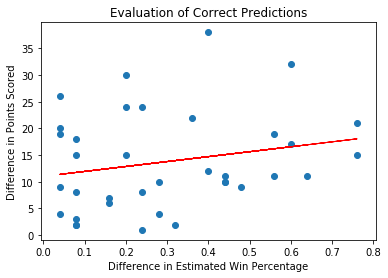

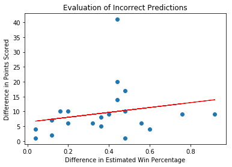

The model can surely be improved in the next few steps.

## Building on the APBRmetrics Model: Accounting for Teamwork and Player Interaction by using "Assists"

We now will enhance the model by integrating teamwork and player interaction, rewarding players who help out their teammates to get the win. It is only natural that teams with great teamwork perform better in a game. We will model teamwork by using the Assists Metric.

We will only model teamwork using 2014 season data because in the 2014 season, the team players are solidified (NBA players are notorious for traveling around and changing teams every season). We cannot model current teamwork using historical player data because players used to be on different teams. The current 2014 season provides teamwork data regarding that team ONLY. For example, LeBron James is currently playing for the Miami Heat. We cannot use his historical "Assists" data from years past because he used to play for the Cleveland Cavaliers. Those historical metrics are not representive of his teamwork skills on the Miami Heat's in the current 2014 season.

We use the Assists Metric because it is a reasonable proxy for teamwork. We will assume a player's teamwork performance, estimated by # of Assists, adds to that player's offensive rating. We do this by weighing the value of an assist. After hours of running the model continuously to find the optimal weight, we find a weight of 1.7 i.e. 1 assist is valued the same as 85% of a clean basket.

**We find the optimal weight to use for assists. The optimal weight is that which gives the highest percentage of correct game outcome predictions.**

**Disclaimer: The following code take an extremely long time to run.**

```
Overall, the model correctly predicts: 56.9% of game outcomes.
For 1 possession games (within 3 pts), the model correctly predicts: 50.0%
For blowout games (score difference is at least 10 pts), the model correctly predicts: 68.8%
```

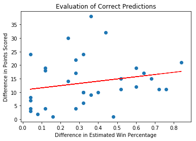

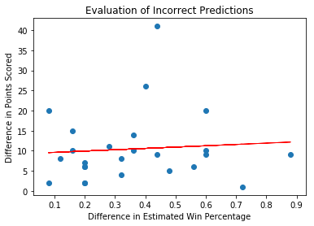

**Scatter Plots** The scatter plots above are quite similar to the scatter plots in the offensive rating only model. However, we realize there is indeed much error, since we are definitely not seeing the ideal positive linear trend (for evaluation of correct predicitions): small differences in win percentages should result in small differences in points scored, and vice-versa. Therefore, there are still many factors the model is not accounting for. An explanation may be that the metric "Assists" is inherently flawed in measuring teamwork. Interactions between players involved much more than a metric, as it involves qualititative traits such as confidence, leadership, charisma, and experience that the model doesn't take into account. Furthermore, teamwork from different types of players are evaluated differently. For example, a Point Guard is supposed to be the go-to-man for setting up plays and making the passes. A team with an excellent Point Guard can be a team with great teamwork. But a team with an equally excellent Center would not perform as well (since a Center stays down low under the hoop and does not run plays).

## Further building on the Points-only model: Accounting for Offense, Teamwork, AND DEFENSE using John Hollinger's "Game Scores"

Basketball analyst John Hollinger uses the metric "Game Scores" to determine a player's entire performance. The Game Score metric accounts for offense, defense, and teamwork, calculated as:

$GmSc = PTS+0.4(FG)-0.7(FGA)-0.4(FTA-FT)+0.7(ORB)+0.3(DRB)+STL$ $+0.7(AST)+0.7(BLK)-0.4(PF)-TOV$

Whereas the models above do not take into account a player's defense capabilities, the metric Game Score uses Defensive Rebounds (DRB) and Blocks (BLK) to estimate defense. Fortunately, the dataset gathered already includes the calculation for Game Score.

http://www.basketball-reference.com/about/glossary.html

#### The COMPLETE process for the same Bayesian Analysis as above but using John Hollinger's "Game Score"

```
Overall, the model correctly predicts: 62.7% of game outcomes.
For 1 possession games (within 3 pts), the model correctly predicts: 66.7%
For blowout games (score difference is at least 10 pts), the model correctly predicts: 71.0%
```

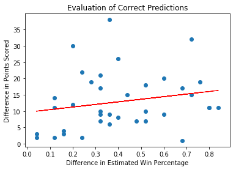

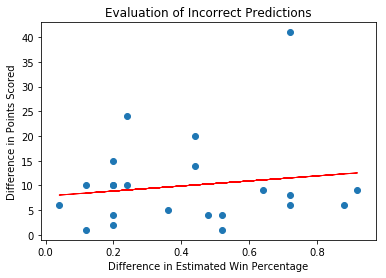

**Interpretion of Model Results and Scatter Plots Above** Looking at the results of the Game Scores model, we see there is not a significant improvement to the offensive ratings model. We notice again, the model predicts blowout games more accurately than predictions overall, reinforcing the notion described above regarding the model's inability to account for qualitative factors such as a team's momentum, confidence the day of the game, quality of coach, etc.

**Scatter Plots** The Scatter Plots are again not improved, which may indicate too much error, possibly in the metric Game Score (GmSc). While GmSc contains metrics that attempt to capture offensive, defensive, and teamwork abilities of players, it may not accurately represent these qualities. Similar to the explanation above, different player positions (point guard, shooting guard, forward, center, etc.), there should also be different weights for different positions. Perhaps a shooting guard is more important to one team's strategy than a forward, etc. The scatter plots indicate that the model is somewhat guessing at the actual result, perhaps indicating the innate volatile nature of basketball, which comes down to a only a few baskets.

### Parallel Coordinates Plots for NBA Divisions using Offensive Rating

We use a Frequentist setting to determine team rankings within Divisions based on overall team rating. We define overall team rating as the average of the top 5 Offensive Ratings per team.

For every year 2009-2013, we will calculate the mean offensive rating for that player and then calculate team rating based on all players in that team.

```
Parallel Coordinates Plot for Team Ratings in the Atlantic Division
```

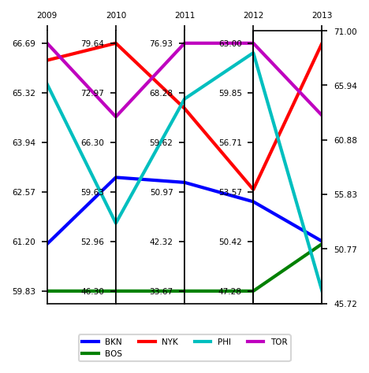

```
Parallel Coordinates Plot for Team Ratings in the Central Division
```

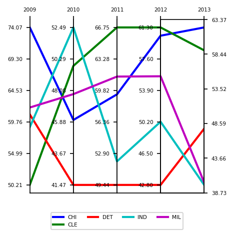

```
Parallel Coordinates Plot for Team Ratings in the NW Division
```

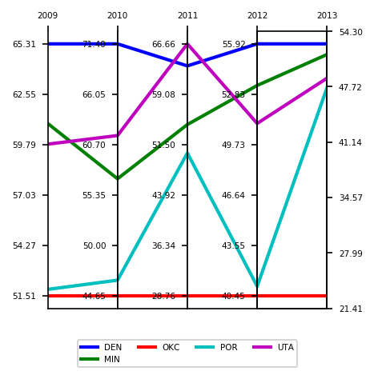

```
Parallel Coordinates Plot for Team Ratings in the Pacific Division
```

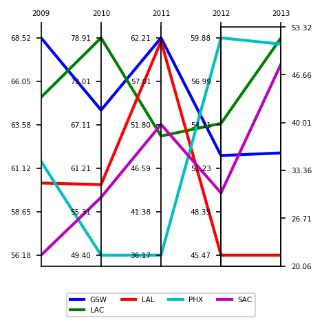

```
Parallel Coordinates Plot for Team Ratings in the SE Division
```

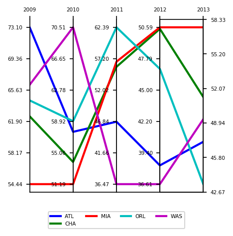

```
Parallel Coordinates Plot for Team Ratings in the SW Division
```

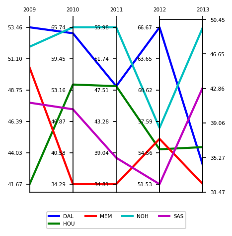

# Building the Bracket

We have now created two models for predicting the outcomes of NBA games. While it is interesting to see the results of regular season games, most sports fans (us included) are interested in the playoffs. We thought it would be interesting to see what our models predict for the 2014 season playoffs, compare our two models against each other, and compare the results of both models to current NBA standings.

In the NBA, which teams make is to the playoffs is determined by the seed, or ranking, of a team within its conferences. The NBA is split into two conferences, East and West. Within each conference, there are 3 divisions. In the East Conference, there are the Atlantic division, the Central division, and the Southeast division. In the West Conference, there are the Northwest division, the Pacific division, and the Southwest division.

In each conference, the top 8 seeds will move on to the playoffs. The first 3 seeds are occupied by the teams with the most wins WITHIN each division. The team with the most number of wins among the divisional winners will be ranked 1st seed, followed by the divisional winner with the second-most wins and the divisional winner with the third-most wins. The remaining 5 seeds are given to the teams with the highest number of wins in the conference, irrespective of their division, in the order of their number of wins. Note here that within this ranking system, it is possible that a 4th seed team has more wins than a 2nd seed team if the 2nd seed team comes from an "easy" division while the 4th seed team comes from a "competitive" division and may have only just missed winning the division by 1 or 2 games.

During the playoffs, the teams are matched against each other based on their seeds, and the winner is whichever team first reaches 4 wins. In the first round, Seed 1 plays Seed 8, 2 plays 7, 3 plays 6, and 4 plays 5. In the second round, the winner of 1 vs. 8 plays the winner of 4 vs. 5 and the winner of 2 vs. 7 plays the winner of 3 vs. 6. In the third round, the two remaining teams play against each other with the winner crowned the conference winner. In the final round, the conference winners play against each other for the NBA championship.

Please find below an illustration of the NBA playoffs:

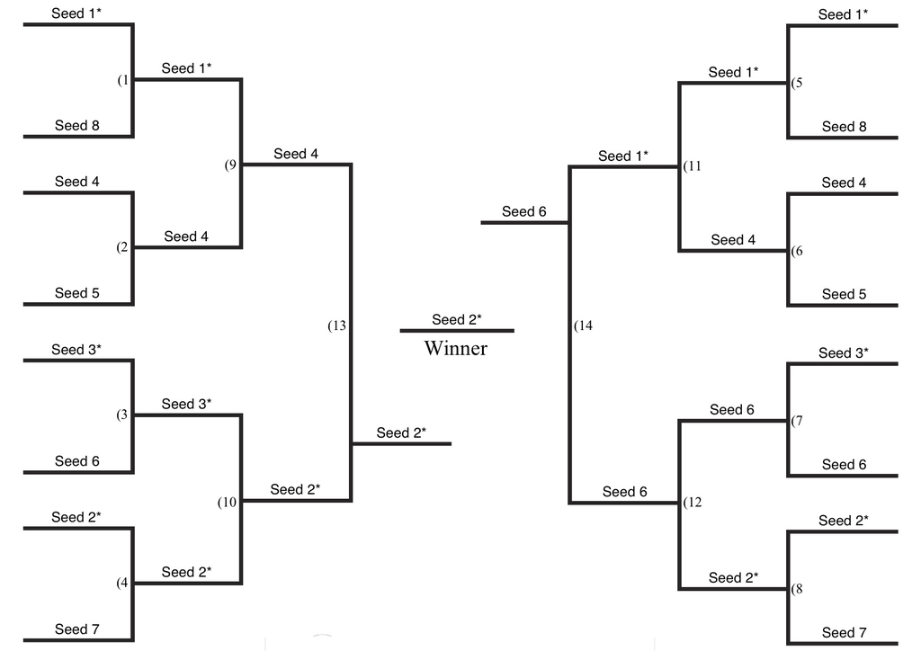

## Simulating the playoffs

First, before we simulate the playoffs, we need to determine the probability that each team makes a seed. From the frequentist models, we will use the margin-adjusted boostrap model due to its high accuracy and low runtime. From the Bayesian models, we will use the Off Rating model adjusted for assists.

### Frequentist Model

First, we will build the seed and playoff simulation using the frequentist model.

```
        1     2     3     4     5     6     7     8 Conference
ATL  0.00  0.00  0.00  0.00  0.00  0.00  0.00  0.00       East
BKN  0.00  0.00  0.00  0.00  0.00  0.00  0.00  0.00       East
BOS  0.00  0.00  0.00  0.92  0.04  0.00  0.04  0.00       East
CHA  0.00  0.00  0.00  0.00  0.02  0.20  0.16  0.26       East
CHI  0.00  0.32  0.24  0.02  0.32  0.04  0.04  0.02       East
CLE  0.00  0.10  0.26  0.04  0.34  0.14  0.08  0.02       East
DAL  0.00  0.00  0.04  0.00  0.02  0.04  0.08  0.16       West
DEN  0.00  0.00  0.00  0.02  0.00  0.02  0.16  0.34       West
DET  0.00  0.06  0.02  0.00  0.16  0.26  0.18  0.18       East
GSW  0.00  0.12  0.00  0.50  0.30  0.06  0.00  0.00       West
HOU  0.00  0.00  0.94  0.00  0.00  0.00  0.02  0.00       West
IND  0.00  0.00  0.00  0.00  0.00  0.00  0.00  0.00       East
LAC  0.08  0.70  0.00  0.12  0.10  0.00  0.00  0.00       West
LAL  0.00  0.10  0.00  0.28  0.34  0.20  0.06  0.02       West
MEM  0.00  0.00  0.00  0.00  0.00  0.00  0.00  0.00       West
MIA  0.00  0.00  0.00  0.00  0.00  0.00  0.06  0.06       East
MIL  0.00  0.00  0.00  0.00  0.00  0.00  0.00  0.00       East
MIN  0.00  0.00  0.00  0.00  0.02  0.06  0.10  0.16       West
NOH  0.00  0.00  0.00  0.00  0.00  0.00  0.00  0.00       West
NYK  1.00  0.00  0.00  0.00  0.00  0.00  0.00  0.00       East
OKC  0.00  0.00  0.00  0.06  0.14  0.42  0.18  0.16       West
ORL  0.00  0.00  0.04  0.00  0.00  0.10  0.16  0.20       East
PHI  0.00  0.00  0.00  0.00  0.00  0.00  0.00  0.00       East
PHX  0.00  0.00  0.00  0.00  0.00  0.00  0.00  0.00       West
POR  0.92  0.08  0.00  0.00  0.00  0.00  0.00  0.00       West
SAC  0.00  0.00  0.00  0.02  0.08  0.18  0.40  0.12       West
SAS  0.00  0.00  0.02  0.00  0.00  0.02  0.00  0.04       West
TOR  0.00  0.00  0.00  0.02  0.12  0.24  0.28  0.24       East
UTA  0.00  0.00  0.00  0.00  0.00  0.00  0.00  0.00       West
WAS  0.00  0.52  0.44  0.00  0.00  0.02  0.00  0.02       East
```

```
defaultdict(<class 'list'>, {4: 'BOS', 8: 'CHA', 2: 'WAS', 5: 'CHI', 6: 'DET', 7: 'TOR', 1: 'NYK', 3: 'CLE'})
defaultdict(<class 'list'>, {8: 'DEN', 4: 'GSW', 3: 'HOU', 2: 'LAC', 5: 'LAL', 6: 'OKC', 1: 'POR', 7: 'SAC'})
```

Once we have our western and eastern conference brackets built, we need to simulate the results of a bracket multiple times. To do this, our basic process is as follows:

- Using predict_bracket to predict the winner between two teams, we simulate all of the games in the bracket 100 times, starting with the first round and ending with the NBA finals. We record in a dictionary when a team makes it to a certain round.
- Like the NBA, two teams play a best of 7 series for each matchup.
- Once we have recorded the number of times each team makes it to each round, we divide this number by the total number of simulations, to find the probability that a team made it to a certain round in the tounament.

First, we will use the frequentist model to create the bracket and the playoff simulations

```
(59, 74)
```

|  | a | b | c | d | team |
| --- | --- | --- | --- | --- | --- |
| BOS | 0.63 | 0.03 | 0.03 | 0.01 | East |
| CHA | 0.01 | 0.01 | 0 | 0 | East |
| CHI | 0.37 | 0 | 0 | 0 | East |
| CLE | 0.67 | 0.29 | 0 | 0 | East |
| DEN | 0.01 | 0 | 0 | 0 | West |
| DET | 0.33 | 0.11 | 0 | 0 | East |
| GSW | 0.47 | 0.14 | 0.08 | 0 | West |
| HOU | 0.49 | 0.18 | 0.05 | 0 | West |
| LAC | 0.86 | 0.7 | 0.31 | 0.09 | West |
| LAL | 0.53 | 0.12 | 0.05 | 0.01 | West |
| NYK | 0.99 | 0.96 | 0.95 | 0.79 | East |
| OKC | 0.51 | 0.08 | 0.01 | 0 | West |
| POR | 0.99 | 0.74 | 0.5 | 0.09 | West |
| SAC | 0.14 | 0.04 | 0 | 0 | West |
| TOR | 0.23 | 0.08 | 0 | 0 | East |

|  | a | b | c | d | team |
| --- | --- | --- | --- | --- | --- |
| BOS | 0.46 | 0.09 | 0.01 | 0 | East |
| CHA | 0.13 | 0.07 | 0.02 | 0 | East |
| CHI | 0.54 | 0.06 | 0.01 | 0 | East |
| CLE | 0.42 | 0.06 | 0 | 0 | East |
| DEN | 0.5 | 0.36 | 0.08 | 0.01 | West |
| DET | 0.58 | 0.12 | 0.02 | 0 | East |
| GSW | 0.61 | 0.25 | 0.02 | 0 | West |
| HOU | 0.73 | 0.46 | 0.36 | 0.12 | West |
| LAC | 0.79 | 0.42 | 0.38 | 0.1 | West |
| LAL | 0.39 | 0.08 | 0.01 | 0 | West |
| NYK | 0.87 | 0.78 | 0.48 | 0.38 | East |
| OKC | 0.27 | 0.09 | 0.04 | 0 | West |
| POR | 0.5 | 0.31 | 0.09 | 0.02 | West |
| SAC | 0.21 | 0.03 | 0.02 | 0.01 | West |
| TOR | 0.8 | 0.7 | 0.43 | 0.34 | East |

Below are screenshots of our final Bokeh visualizations. Because of some complications with Bokeh, we were forced to place the code in a different iPython notebook. For the code for the final visualizations of our brackets, please see Final Bracket Visualization.ipynb.

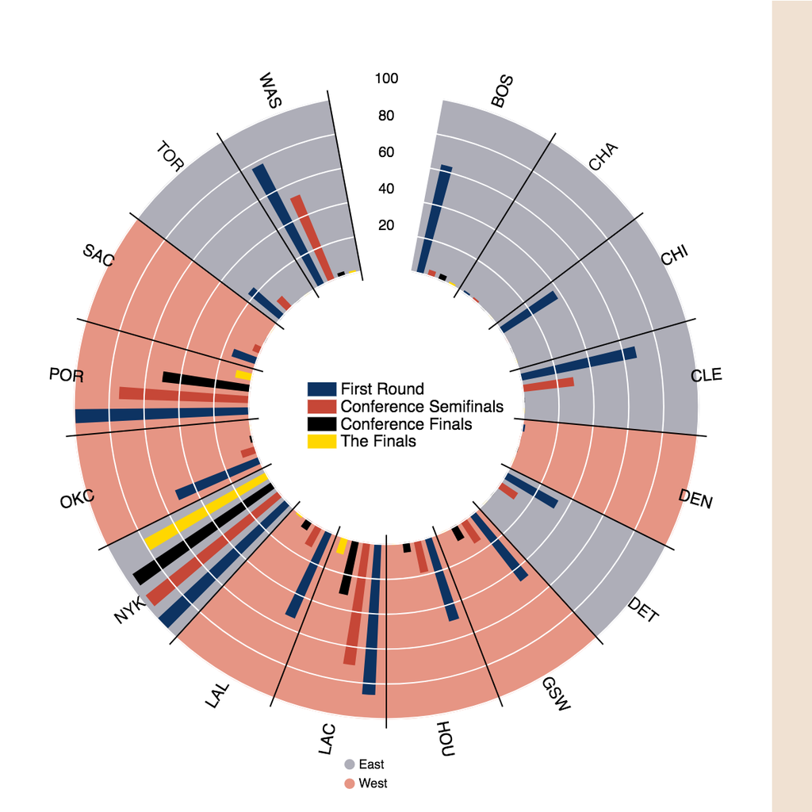

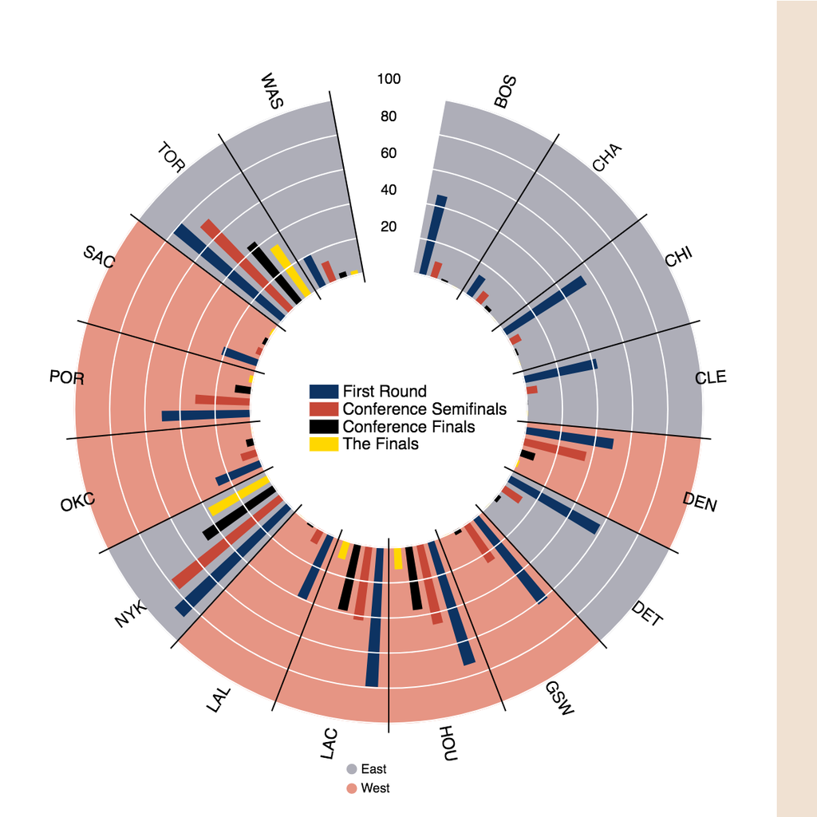

### Analysis

One of the original driving goals of the project was to predict the probability of each team winning the NBA championship. Instead of returning the single most likely team to win the championship, we wanted to determine and visually show the probability of different teams making it to a certain level in the playoffs. Using the bracket simulation method (as described above) and our models for predicting the outcomes of games, we simulated a large number of possible brackets. According to this frequentist approach, the New York Knicks are highly predicted to win the NBA championship (around 79% probability). While the Knick’s aren’t exactly playing well this season, they played very well in the last few seasons (with Linsanity and Carmelo’s high scoring antics), which resulted in their prowess in our predictions.

We used both a Frequentist model and a Bayesian model to create the brackets and simulate playoff. Both models predicted a high probability for the New York Knicks to win the NBA championship. Both models also predict the Los Angeles Clippers to win the championship. The Bayesian approach also assigns modest probabilities to the Toronto Raptors and Houston Rockets. Based on the caliber of their veteran players and in the way that they were matched up in the playoffs, these teams have a good chance of making it to the end, but not as high as a team like the New York Knicks.

# Conclusion and Remarks

In modeling our data, we started with a very basic predictive model that was based off of the historical scores between two teams. By sampling many times from the scoring results of a historical set of games, we made predictions on the results of games between two specified teams. In comparing this model with the true results of games in the 2012-2013 season, we found that this baseline frequentist model, based on game scores, was able to predict the outcomes of games with around 65% accuracy. In the 2013-2014, we found that the accuracy of the model fell to around 55%. However, the 2013-2014 season is still young, and the actual results of the season may be skewed with many outliers. As the season progresses, we hypothesize that our predictions will become more accurate, as there will be more games to compare our results to.

One criticism of this model is that it treats every historical scoring outcome with equal weight. To improve it, it might be more accurate if the model is able to rate more recent games more heavily, since more recent game outcomes should more accurately reflect future play. Another area for future investigation is whether more historical data actually hinders the accuracy of the model as players’ skills fluctuate from year to year; perhaps we should have just sampled from last year’s data or from trailing 20 games.

There are two key takeaway from the Bayesian Analysis.

Areas for improvement:

1. Determining how many year/seasons to go back in building data for a prior is quite important . Perhaps it doesn’t make sense to go back 5 seasons, since players’ offensive capabilities have grown more consistent over the years. However, we thought 5 seasons would be a reasonable start and given more time, we could have explored different sets of data for the prior that would give us the most accurate predictions.
2. Modeling teamwork is very tricky, and the metric “Assists” may not do teamwork enough justice. Teamwork involves team chemistry, charisma, and experience that appears on the court but likely not in the metrics. The innate nature of an assist (calculated as a pass that leads to a basket) is flawed because in basketball, it is quite common for players to “swing” the ball multiple times until a teammate finds an open shot, which should definitely be considered a teamwork skill. The same argument goes for a player’s ability to make accurate and consistent passes to teammates.
3. Modeling history of team performance could perhaps enhance results. The bayesian model do not take into account a team playing another team for the second time during a season. It was difficult to account for since players switch around team very often. However, the frequentist model did take into account team historical performance against other teams, and the improvements were marginal if not insignificant.

In sum, a big picture view of the frequentist and bayesian models reveal that there is no dramatic improvement of the model’s prediction accuracy by use more metrics. The Bayesian approach, involving complicated metrics such as Offensive Rating and Game Score do not do much better than a standard Points-only model, although one would expect that metrics accounting for teamwork and defensive capabilities would increase prediction accuracy. Furthermore, there may be multicollinearity in the model because metrics are dependent i.e. a player with high points probably also has high number of assists, offensive rebounds, field goals, etc. Thus, the models demonstrate that metrics can only do so much in predicting games. From a points-only model to a 12 metric model (Game Scores), the prediction accuracy is still only around 55-65%.

The team came to realize that unlike other team sports such as football and baseball, basketball is an extraordinarily volatile sport where a majority of games come down to only a few baskets. Furthermore, there is NO other sport in which one player can just go OFF...Unlike any other team sport, an NBA player can have an amazing day one game, taking the ENTIRE team to a win single-handedly and a poor day another. More so than in other sports, basketball has a big luck component and other key variables that are difficult to model. Metrics just cannot account for important key variables such as coaching ability, injuries, confidence, experience, and when a player simply “feels it” (for ex: knocking down ten 3-pointers in a row). Based on the natural volatility of basketball, the team though the models were in-line with expectations. The model could surely do better than a coin flip, but not by much due to the important qualitative factors of basketball we are not able to address. Therefore, a model with about 60% accuracy should be considered reasonably good from a quantitative-only perspective.